# Lokaverkefni í R fyrir byrjendur

Þórgnýr Thoroddsen

19 September 2016

### Verkefni 1: Tilgreinið fjölda eigna í Vestmannaeyjum í gagnasafninu.

Við skulum byrja á að hlaða gagnasafninu í hlut sem við köllum *fasteignir*. Það gerum við með *read.table()* skipuninni. Því næstu einföldum við gagnaskránna með því að draga út þá dálka sem við munum nota í verkefninu.

```r
fasteignir <- read.table("gagnasafn_endurmat2017_iso.csv", header = T, sep = ",", na.strings = "(null)", fileEncoding = "latin1")
einfaldad <- fasteignir[,c(4,8,9,27,28,31,48,49,51)]
```

[Á þessarri vefsíðu](http://www.skra.is/library/Samnyttar-skrar-/Fasteignamat-2017/2016_LANDSBYGGD_IBU_v2.pdf) má sjá kort með yfirliti yfir matssvæði eigna. Þar sjáum við að eignir í Vestmannaeyjum eru skráðar með kóðanum 8200. Með því móti getum við fundið út fjölda eignanna á einfaldan hátt.

```r
sum(einfaldad$matssvaedi == 8200)
```

```
## [1] 447
```

### Verkefni 2: Fjarlægið eignir sem eru ekki skilgreindar sem Einbýlishús, Íbúðareign, Parhús eða Raðhús. Notið einungis þessar gerðir eigna það sem eftir er verkefnisins.

Það gerum við á eftirfarandi hátt.

```r
einfaldad <- einfaldad[einfaldad$teg_eign == "Einbýlishús" | einfaldad$teg_eign == "Íbúðareign" | einfaldad$teg_eign == "Parhús" | einfaldad$teg_eign == "Raðhús", ]
```

### Verkefni 3: Tilgreinið hversu margar eignir af hverri gerð eru á Seltjarnarnesi, Garðabæ og í Mosfellsbæ (einbýlishús, íbúðareign, parhús, raðhús).

Hér gerum við nýjan gagnaramma sem inniheldur bara upplýsingar um tegund eignar og auðkenni sveitarfélags. Við gerum *svfn* breytuna að *factor* og breytum gildunum í nafnið á umræddum sveitarfélögum. Þar sem gildin raðast eftir stærðarröð þá nægir fyrir mig að skrifa nöfnin í þeirri röð sem stærðirnar segja til um. Því næst keyri ég *droplevels*, en sú skipun tekur út ónotuð *levels* (sem þó sjást ekki í gagnarammanum). Síðast set ég síðan gögnin í töflu.

```r
sp3_dataframe <- einfaldad[c(einfaldad$svfn == 1100 | einfaldad$svfn == 1300 | einfaldad$svfn == 1604),]
sp3_dataframe$svfn <- as.factor(sp3_dataframe$svfn)
levels(sp3_dataframe$svfn) <- c("Seltjarnarnes", "Garðabær", "Mosfellsbær")
sp3_dataframe$teg_eign <- droplevels(sp3_dataframe$teg_eign)
table(sp3_dataframe$teg_eign, sp3_dataframe$svfn)
```

```
##
##               Seltjarnarnes Garðabær Mosfellsbær
##   Einbýlishús            77      384         152
##   Íbúðareign            347     1013         448
##   Parhús                 23       51          46
##   Raðhús                 52      225         134
```

### Verkefni 4: Teiknið mynd sem er lýsandi fyrir fjölda eigna af hverri gerð í sveitafélögunum þremur hér að ofan.

Hér búum við til stöplarit sem að lýsir fjölda og samsetningu eigna í sveitarfélögunum. Við byrjum á því að hlaða inn *ggplot2* skipanasafninu. Stöplaritið er skilgreint með *geom_bar()* og með *scale_fill_discrete()* skipunin er síðan notuð til að gera tegundastafla í stöplunum.

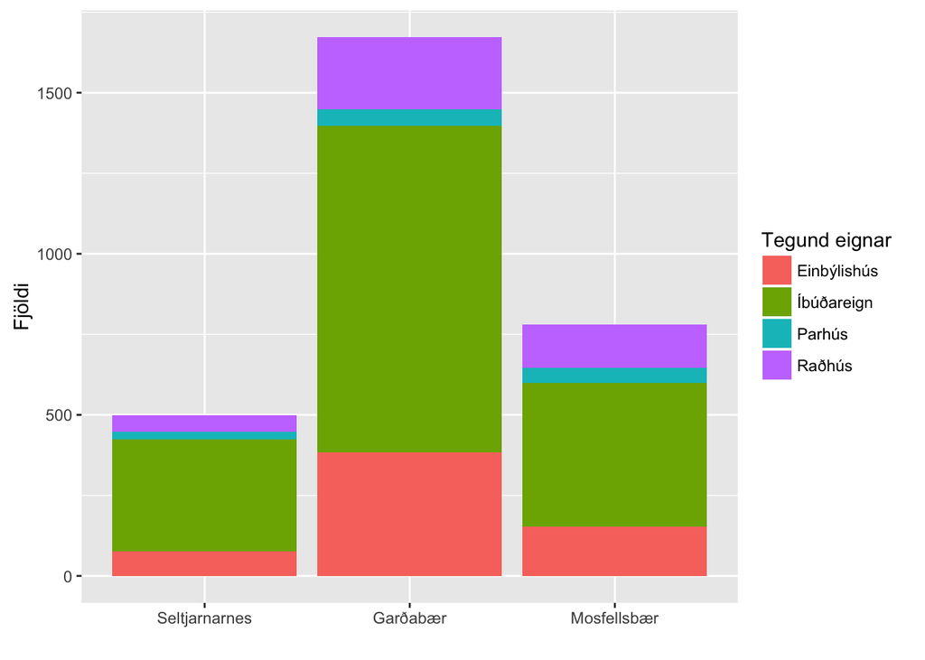

```r
library(ggplot2)
sp3_dataframe <- sp3_dataframe[2:3]
g <- ggplot(sp3_dataframe, aes(x=svfn, fill = teg_eign)) + geom_bar() + xlab("") + ylab("Fjöldi") + scale_fill_discrete(name = "Tegund eignar", labels = c("Einbýlishús", "Íbúðareign", "Parhús", "Raðhús"))
g
```

### Verkefni 5: Búið til nýtt gagnasafn sem inniheldur aðeins eignir í Reykjavík.

Þetta gerum við einfaldlega með því að skrifa í snatri

```r
reykjavik <- einfaldad[einfaldad$svfn == 0, ]
```

### Verkefni 6: Tilgreinið meðalverð einbýlishúsa, íbúða, parhúsa og raðhúsa í Reykjavík. Er meðaltal góður mælikvarði á miðju í þessum tilfellum?

Við notum *mean()* skipunina á núvirðisdálk reykjavíkurgagnasettsins og sjáum meðaltalið.

```r
mean(reykjavik$nuvirdi)
```

```
## [1] 29663.17
```

```r
median(reykjavik$nuvirdi)
```

```
## [1] 25993
```

### Verkefni 7: Tilgreinið meðalstærð og miðgildi stærðar einbýlishúsa, íbúða, parhúsa og raðhúsa í Reykjavík.

Með sömu skipun og að ofan skoðum við meðalstærð og miðgildi einbýlishúsa, íbúða, parhúsa og raðhúsa í Reykjavík.

Meðalstærð einbýlishúsa í Reykjavík er 184.934 Miðgildi stærðar einbýlishúsa í Reykjavík er 179.4

Meðalstærð íbúðareigna í Reykjavík er 85.9194863 Miðgildi stærðar íbúðareigna í Reykjavík 83.2

Meðalstærð parhúsa í Reykjavík er 149.4701031 Miðgildi stærðar parhúsa í Reykjavík er 151.5

Meðalstærð raðhúsa í Reykjavík er 161.8966279 Miðgildi stærðar raðhúsa í Reykjavík er 160.45

### Verkefni 8: Teiknið mynd sem sýnir mun á verði eigna eftir gerð í Reykjavík (einbýlishús, íbúðareign, parhús, raðhús).

Hér þurfum við að setja upp svokallað kassarit með *geom_boxplot()* skipuninni. Miðlína hvers kassa tilgreinir miðgildi gagnanna. Efri og neðri brún kassanna tilgreina fjórðungamörk gagnanna, það er að segja, fyrir ofan kassann eru 25% allra gagna, og öfugt. Línurnar skilgreina síðan dreifingu afgangsins, að útlögum undanskyldum.

Mér þótti fjöldi útlaga vera furðu mikill. Af þeim sökum vildi ég skoða dreifingu punktanna betur. Með *geom_jitter()* gat ég sýnt dreifingu punktanna betur og liðið ögn betur með hvað útlagarnir eru margir.

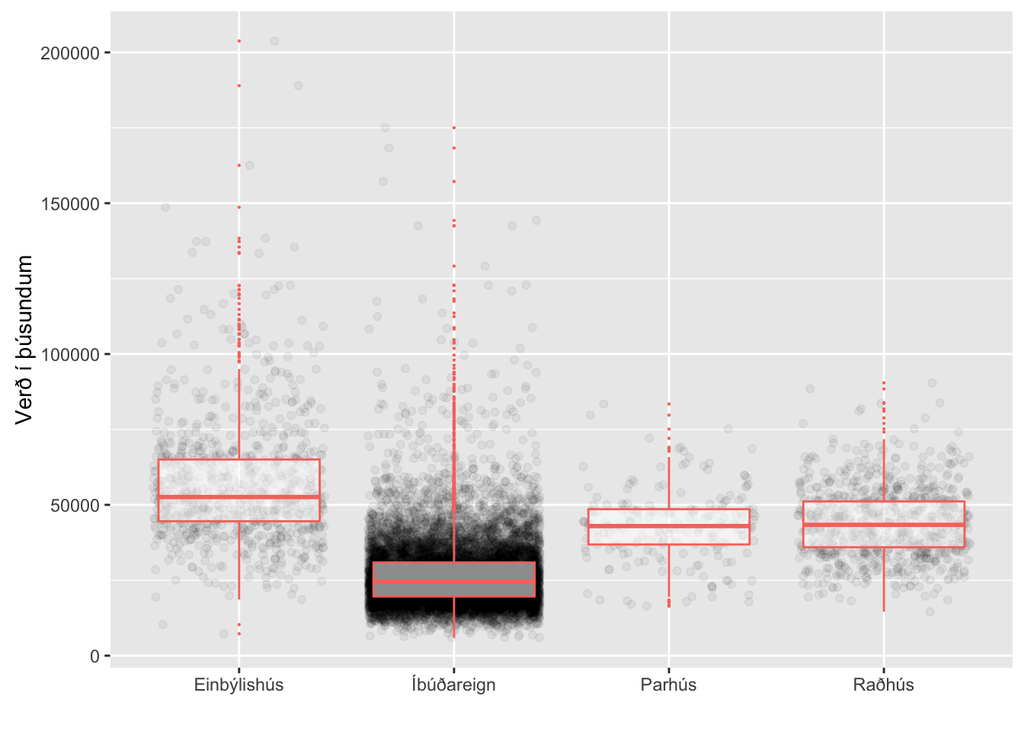

```r
g2 <- ggplot(reykjavik, aes(x=teg_eign, y=nuvirdi, colour = "#3366FF", alpha = 0.1)) + geom_jitter(alpha = 0.05, colour = "black") + geom_boxplot(outlier.size = 0.1) + xlab("") + ylab("Verð í þúsundum") + theme(legend.position = "none")
g2
```

### Verkefni 9: Teiknið mynd sem sýnir samband stærðar og verðs á íbúðareignum í Reykjavík.

Við gerum punktarit með *geom_point()* skipuninni.

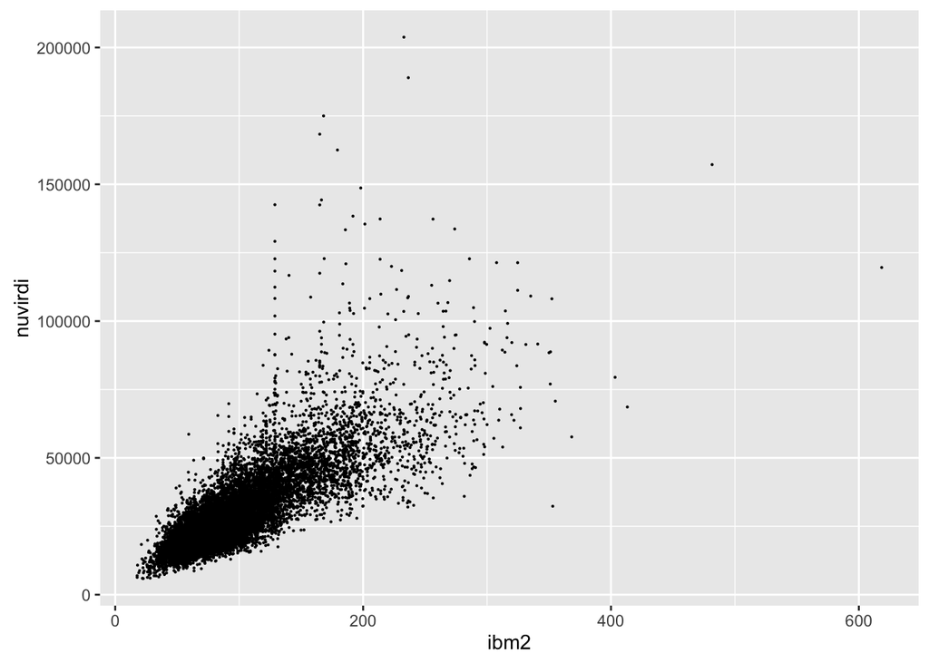

```r
g3 <- ggplot(reykjavik, aes(x=ibm2, y=nuvirdi)) + geom_point(size = 0.1)
g3
```

### Verkefni 10: Veljið handahófskennt 500 íbúðareignir úr hverfunum “Laugarneshverfi/Vogar”, “Grafarvogur: Rimar, Engi, Víkur, Borgir” og “Seljahverfi”. Gerum nú ráð fyrir að þessar 500 eignir séu slembiúrtak af eignum í þessum hverfum tekið úr fasteignaskrá. Það sem eftir er verkefnisins eigið þið aðeins vinna með þetta gagnasafn.

Byrjum á að búa til gagnasafn sem inniheldur allar íbúðareignir í umræddum hverfum. Við notum síðan *cut()* og *levels()* skipanirnar til að breyta matssvæðisnúmerunum í nöfn hverfanna.

Þá búum við til svokallað *seed* til þess að gera endurtakanlegt slembiúrtak úr safninu. Í þetta skiptið ætla ég að nota fæðingardag minn. Við skilgreinum síðan *n* sem lengd gagnasafnsins. Að því loknu tökum við sýni úr safninu með *sample()* skipuninni. Skipunin tekur tvo parametera, *n* sem er stærð safnsins, og 500 sem er fjöldi sýna úr safninu.

```r
r500 <- reykjavik[reykjavik$matssvaedi == 100 | reykjavik$matssvaedi == 130 | reykjavik$matssvaedi == 150,]
r500 <- r500[r500$teg_eign == "Íbúðareign",]
r500$matssvaedi <- cut(r500$matssvaedi, c(0, 100, 130, 150))
levels(r500$matssvaedi) <- c("Laugarneshverfi og Vogar", "Grafarvogur: Rimar, Engi, Víkur, Borgir", "Seljahverfi")
random <- set.seed(250382)
n <- dim(r500)[1]
x500 <- sample(n, 500)
r500 <- r500[x500,]
```

### Verkefni 11: Búið til nýja flokkabreytu sem flokkar íbúðaeignir í litlar, meðal og stórar íbúðaeignir. Litlar eignir eiga að vera þær sem eru minni en 60 $m^2$ að stærð, Meðalstórar þær sem eru á bilini 60 - 90 $m^2$ á stærð (60 og 90 meðtalin) og stórar eignir þær sem eru stærri en 90 $m^2$ að stærð.

```r
r500$staerdarflokkur <- cut(r500$ibm2, c(0, 60, 90.1, max(r500$ibm2, na.rm = TRUE)), right=F)
levels(r500$staerdarflokkur) <- c("Lítil Eign","Meðalstór Eign", "Stór Eign")
```

### Verkefni 12: Búið til töflu sem sýnir hversu hátt hlutfall eigna eru í hverjum stærðarflokki í hverfunum þremur.

Notum *prop.table()* skipunina til að gera töflu sem sýnir okkur hlutfall eigna í hverjum stærðarflokki.

```r
prop.table(table(r500$matssvaedi, r500$staerdarflokkur), margin = 1)
```

```
##
##                                           Lítil Eign Meðalstór Eign
##   Laugarneshverfi og Vogar                0.14652015     0.43956044
##   Grafarvogur: Rimar, Engi, Víkur, Borgir 0.02702703     0.50675676
##   Seljahverfi                             0.10256410     0.43589744
##
##                                            Stór Eign
##   Laugarneshverfi og Vogar                0.41391941
##   Grafarvogur: Rimar, Engi, Víkur, Borgir 0.46621622
##   Seljahverfi                             0.46153846
```

### Verkefni 13: Kannið, með viðeigandi tilgátuprófi, hvort munur sé á meðalverði meðalstórra íbúðareigna í hverfunum þremur eftir því hvort þær eru með baðkar eða ekki.

Hér gerum við nýja breytu sem að sýnir meðalstórar eignir eingöngu. Við breytum baðkarabreytunni á þann hátt að ef það er eitt eða fleiri baðkör, þá fær hún gildið *1*. Við skoðum síðan töflu sem sýnir fjölda eigna án baðkars annarsvegar, og fjölda með baðkar hinsvegar.

```r
medalbkar <- r500[r500$staerdarflokkur == "Meðalstór Eign", ]
medalbkar$fjbkar[medalbkar$fjbkar >0] <- "1"
table(medalbkar$fjbkar)
```

```
##
##   0   1
##  64 165
```

Við skulum nú framkvæma *t-Test* þar sem við berum saman meðalverð eigna í hverfunum þremur með tilliti til þess hvort baðkar sé til staðar eða ekki.

```r
t.test(medalbkar$nuvirdi~medalbkar$fjbkar)
```

```
##
##  Welch Two Sample t-test
##
## data:  medalbkar$nuvirdi by medalbkar$fjbkar
## t = 0.61021, df = 97.237, p-value = 0.5431
## alternative hypothesis: true difference in means is not equal to 0
## 95 percent confidence interval:
##  -1058.111  1997.646
## sample estimates:
## mean in group 0 mean in group 1
##        23200.23        22730.47
```

### Verkefni 14: Kannið, með viðeigandi tilgátuprófi, hvort munur sé á meðalverði meðalstórra íbúðareigna eftir hverfum. Ef svo er, kannið hvar sá munur liggur.

Hér notum við svokallað *Tukey* próf til að bera saman meðaltöl meðalstórra íbúðareigna eftir hverfum.

```r
fit.aov<-aov(nuvirdi ~ matssvaedi, data=medalbkar)
TukeyHSD(fit.aov)
```

```
##   Tukey multiple comparisons of means
##     95% family-wise confidence level
##
## Fit: aov(formula = nuvirdi ~ matssvaedi, data = medalbkar)
##
## $matssvaedi
##                                                                       diff
## Grafarvogur: Rimar, Engi, Víkur, Borgir-Laugarneshverfi og Vogar -440.3583
## Seljahverfi-Laugarneshverfi og Vogar                              240.8044
## Seljahverfi-Grafarvogur: Rimar, Engi, Víkur, Borgir               681.1627
##                                                                        lwr
## Grafarvogur: Rimar, Engi, Víkur, Borgir-Laugarneshverfi og Vogar -2103.942
## Seljahverfi-Laugarneshverfi og Vogar                             -1954.925
## Seljahverfi-Grafarvogur: Rimar, Engi, Víkur, Borgir              -1655.477
##                                                                       upr
## Grafarvogur: Rimar, Engi, Víkur, Borgir-Laugarneshverfi og Vogar 1223.225
## Seljahverfi-Laugarneshverfi og Vogar                             2436.534
## Seljahverfi-Grafarvogur: Rimar, Engi, Víkur, Borgir              3017.802
##                                                                      p adj
## Grafarvogur: Rimar, Engi, Víkur, Borgir-Laugarneshverfi og Vogar 0.8068304
## Seljahverfi-Laugarneshverfi og Vogar                             0.9637746
## Seljahverfi-Grafarvogur: Rimar, Engi, Víkur, Borgir              0.7708795
```

```r
medalbkar <- medalbkar[-88, ]
mean(medalbkar$nuvirdi[medalbkar$matssvaedi == "Laugarneshverfi og Vogar"])
```

```
## [1] 22970.22
```

```r
mean(medalbkar$nuvirdi[medalbkar$matssvaedi == "Grafarvogur: Rimar, Engi, Víkur, Borgir"])
```

```
## [1] 22529.87
```

```r
mean(medalbkar$nuvirdi[medalbkar$matssvaedi == "Seljahverfi"])
```

```
## [1] 23211.03
```

### Verkefni 15: Smíðið línulegt líkan sem lýsir sambandi stærðar og verði íbúðareigna í hverfinu “Laugarneshverfi/Vogar”. Tilgreinið í samfelldu máli gildin á mötunum á stikunum í líkaninu. Tilgreinið hvert skýringarhlutfallið er og túlkið hvað það merkir. Er í lagi að nota línulegt líkan til að lýsa þessu sambandi?

```r
fyrirmodel <- r500[r500$matssvaedi =="Laugarneshverfi og Vogar" | r500$teg_eign == "Íbúðareign",]
model <- lm(nuvirdi ~ ibm2, data = fyrirmodel)
summary(model)
```

```
##
## Call:
## lm(formula = nuvirdi ~ ibm2, data = fyrirmodel)
##
## Residuals:
##      Min       1Q   Median       3Q      Max
## -14313.2  -3367.3   -357.1   3136.4  19403.3
##
## Coefficients:
##             Estimate Std. Error t value Pr(>|t|)
## (Intercept) 3129.193    819.390   3.819 0.000151 ***
## ibm2         251.298      8.842  28.419  < 2e-16 ***
## ---
## Signif. codes:  0 '***' 0.001 '**' 0.01 '*' 0.05 '.' 0.1 ' ' 1
##
## Residual standard error: 4949 on 498 degrees of freedom
## Multiple R-squared:  0.6186, Adjusted R-squared:  0.6178
## F-statistic: 807.7 on 1 and 498 DF,  p-value: < 2.2e-16
```

Ég tel að það sé réttlætanlegt að nota línulegt líkan til að lýsa þessu sambandi stærðar og verðs, en *p-gildi* módelsins er afar lágt, sem gefur vísbendingu um að fylgnin sé nokkuð áreiðanleg.